# LLM vs. Human Ratings

## Overview

This page compares the LLM‑generated ratings (`gpt-5`) from the(previous section with human evaluations across [the Unjournal’s criteria](https://globalimpact.gitbook.io/the-unjournal-project-and-communication-space/policies-projects-evaluation-workflow/evaluation/guidelines-for-evaluators#undefined-1). We (i) harmonize the two sources to a common set of metrics and paper IDs, (ii) compute paired scores per *(paper, metric)*, and (iii) summarize agreement using distributional views and reliability statistics.

## Data & Harmonization

- Sources. LLM ratings come from `results/metrics_long.csv` (rendered in the previous chapter). Human ratings are imported from your hand‑coded spreadsheet and mapped to LLM paper IDs via `UJ_map.csv`.
- Metric alignment. Human criteria are recoded to the LLM schema (e.g., `claims` → `claims_evidence`, `adv_knowledge` → `advancing_knowledge`, etc.). If humans provided both `gp_relevance` and `real_world`, we fold these into the single LLM metric `global_relevance`.
- Uncertainty fields. Where available, we carry lower/upper bounds for both LLM and humans; these are used in optional uncertainty checks but do not affect the mid‑point comparisons below.

```python
import os, re, math
import numpy as np
import pandas as pd
import matplotlib.pyplot as plt
from matplotlib.colors import LinearSegmentedColormap
from scipy.stats import pearsonr, spearmanr

# Glue for inline text (MyST)
try:
    from myst_nb import glue
except Exception:
    # Fallback: still define a function so doc runs; inline {{glue: ...}} needs myst-nb installed.
    def glue(name, val, display=False):
        globals()[name] = val


# Matplotlib defaults for a clean look
plt.rcParams.update({
    "figure.dpi": 120,
    "axes.spines.top": False,
    "axes.spines.right": False,
    "axes.grid": True,
    "grid.alpha": 0.25,
    "axes.titlesize": 11,
    "axes.labelsize": 10,
    "legend.fontsize": 9
})
# ---- Unjournal brand palette (hex) --------------------------------
# From theme SCSS:
#   $unjournal-green:  #99bb66
#   $unjournal-orange: #f19e4b
UJ_ORANGE = "#f19e4b"   # LLM
UJ_GREEN  = "#99bb66"   # Human

# Helpers to make brand-consistent variants & Plotly-friendly RGBA
import colorsys
from matplotlib import colors as mcolors
from matplotlib.colors import LinearSegmentedColormap

def adjust_lightness(hex_color: str, factor: float = 0.80) -> str:
    """
    Darken/lighten a color by scaling lightness in HLS.
    factor < 1 → darker; factor > 1 → lighter. 0.80 ≈ 20% darker.
    """
    r, g, b = mcolors.to_rgb(hex_color)
    h, l, s = colorsys.rgb_to_hls(r, g, b)
    l = max(0, min(1, l * factor))
    r2, g2, b2 = colorsys.hls_to_rgb(h, l, s)
    return mcolors.to_hex((r2, g2, b2))

def rgba_hex(hex_color: str, alpha: float) -> str:
    """Convert hex '#rrggbb' → 'rgba(r,g,b,a)' for Plotly."""
    r, g, b = mcolors.to_rgb(hex_color)
    return f"rgba({int(round(255*r))},{int(round(255*g))},{int(round(255*b))},{alpha})"

# Darker accents (same hue) for outlines & heatmap extremes
UJ_ORANGE_D = adjust_lightness(UJ_ORANGE, 0.78)  # ~22% darker
UJ_GREEN_D  = adjust_lightness(UJ_GREEN,  0.72)  # ~28% darker

# Diverging map using brand colors with darker extremes and soft center
def make_uj_div():
    return LinearSegmentedColormap.from_list(
        "uj_div_brand",
        [
            (0.00, UJ_GREEN_D),            # deep brand green
            (0.40, UJ_GREEN),              # main brand green
            (0.50, "#f7f7f7"),             # neutral center
            (0.60, UJ_ORANGE),             # main brand orange
            (1.00, UJ_ORANGE_D)            # deep brand orange
        ],
        N=256
    )

UJ_DIV = make_uj_div()  # used by both heatmaps



from matplotlib.colors import TwoSlopeNorm, LinearSegmentedColormap  # add TwoSlopeNorm
```

```python
# Files
LLM_FILE   = "results/metrics_long.csv"
HUMAN_FILE = "UJ_ratings/rsx_evalr_rating (7).csv"
IMAP_FILE  = "UJ_ratings/UJ_map.csv"

llm   = pd.read_csv(LLM_FILE)
human = pd.read_csv(HUMAN_FILE)
imap  = pd.read_csv(IMAP_FILE)

# 1) Map human 'criteria' → LLM metric names
crit_map = {
    "overall":          "overall",
    "claims":           "claims_evidence",
    "methods":          "methods",
    "adv_knowledge":    "advancing_knowledge",
    "logic_comms":      "logic_communication",
    "open_sci":         "open_science",
    "gp_relevance":     "global_relevance",
    "real_world":       "global_relevance",  # fold-in
    "merits_journal":   None,
    "journal_predict":  None
}
human["metric"] = human["criteria"].map(crit_map)
human = human[human["metric"].notna()].copy()

# 2) Normalize titles to join robustly
def _norm_title(s: str) -> str:
    s = str(s)
    s = s.replace("’", "'").replace("–","-").replace("—","-")
    s = re.sub(r"\s+", " ", s).strip()
    return s

human["research_norm"] = human["research"].map(_norm_title).str.lower()
imap["research_norm"]  = imap["research"].map(_norm_title).str.lower()

# 3) Attach LLM paper id to human rows
human = human.merge(imap[["paper","research_norm"]], on="research_norm", how="left")

# 4) Diagnostics
missing_id  = sorted(human[human.paper.isna()]["research"].unique())
missing_llm = sorted(set(llm.paper.unique()) - set(human.paper.dropna().unique()))
# if missing_id:
#     print("⚠️ Human titles without LLM id (fill 'paper' in UJ_map.csv):")
#     for t in missing_id: print("   •", t)
# if missing_llm:
#     print("\n⚠️ LLM papers with no human match:")
#     for p in missing_llm: print("   •", p)

# 5) Collapse human repeats to means (per paper×metric)
human_use = (human
    .dropna(subset=["paper","metric","middle_rating"])
    .groupby(["paper","metric"], as_index=False)
    .agg(midpoint_human=("middle_rating","mean"),
         lower_human   =("lower_CI","mean"),
         upper_human   =("upper_CI","mean"),
         n_human       =("middle_rating","size"))
)

# 6) Select/rename LLM columns
llm_use = (llm[["paper","metric","midpoint","lower_bound","upper_bound"]]
           .rename(columns={"midpoint":"midpoint_llm",
                            "lower_bound":"lower_llm",
                            "upper_bound":"upper_llm"}))

# 7) Merge pairs
merged = llm_use.merge(human_use, on=["paper","metric"], how="inner")

# print(f"✅ merged rows: {len(merged)}  "
#       f"({merged.paper.nunique()} papers × {merged.metric.nunique()} metrics)")

# Long form for distribution plots
ratings_long = pd.concat([
    merged[["paper","metric","midpoint_llm"]]
        .rename(columns={"midpoint_llm":"score"}).assign(rater="LLM"),
    merged[["paper","metric","midpoint_human"]]
        .rename(columns={"midpoint_human":"score"}).assign(rater="Human")
], ignore_index=True)
```

```python
# Keep per‑rater rows (after mapping; before averaging)
human_raw = human.dropna(subset=["paper","metric","middle_rating"]).copy()

# Try to detect a rater id column; otherwise make one per (paper, metric)
cands = [c for c in human_raw.columns if c.lower() in
         ["rater","reviewer","evaluator","coder","annotator","user","name",
          "id","uid","user_id","evaluator_id","reviewer_id"]]
if cands:
    rid_col = cands[0]
    human_raw["rater_id"] = human_raw[rid_col].astype(str)
else:
    human_raw["rater_id"] = (human_raw
                             .groupby(["paper","metric"])
                             .cumcount()
                             .add(1)
                             .map(lambda i: f"R{i}"))

# One row per paper×metric with LLM midpoint (for joining)
llm_single = llm_use[["paper","metric","midpoint_llm"]].drop_duplicates()
```

```python
def pair_llm_human(df: pd.DataFrame) -> pd.DataFrame:
    """Return (paper, metric, LLM, Human) single-row pairs."""
    return (df[["paper","metric","midpoint_llm","midpoint_human"]]
            .dropna()
            .rename(columns={"midpoint_llm":"LLM","midpoint_human":"Human"}))

def bin_together(a, b, n_bins=5, strategy="quantile"):
    """
    Bin two continuous arrays with shared edges (for κ).
    - 'quantile' bins are robust to skew.
    - fallback to equal-width if quantiles collapse.
    """
    both = pd.Series(np.r_[a, b]).dropna()
    if both.nunique() <= max(3, n_bins):
        # Already discrete-ish: map unique sorted values to 0..K-1
        uniq = np.sort(both.unique())
        mapping = {v:i for i,v in enumerate(uniq)}
        return np.vectorize(mapping.get)(a), np.vectorize(mapping.get)(b), len(uniq)
    if strategy == "quantile":
        qs = both.quantile(np.linspace(0, 1, n_bins+1)).values
        edges = np.unique(qs)
        if len(edges) - 1 < 2:
            strategy = "equal"
    if strategy == "equal":
        lo, hi = float(both.min()), float(both.max())
        edges = np.linspace(lo, hi, n_bins+1)
    edges[0] -= 1e-9; edges[-1] += 1e-9
    a_bin = pd.cut(a, bins=edges, labels=False, include_lowest=True)
    b_bin = pd.cut(b, bins=edges, labels=False, include_lowest=True)
    k = int(np.nanmax([a_bin.max(), b_bin.max()]) + 1)
    return np.asarray(a_bin), np.asarray(b_bin), k

def weighted_kappa(a, b, k=None, weights="quadratic"):
    """
    Cohen's weighted kappa for ordinal labels 0..k-1.
    weights: 'quadratic' (default), 'linear', or None (unweighted).
    """
    a = np.asarray(a, dtype=int)
    b = np.asarray(b, dtype=int)
    if k is None:
        k = int(max(a.max(), b.max()) + 1)
    if k <= 1:  # not enough categories
        return np.nan

    # Observed agreement matrix (proportions)
    M = np.zeros((k, k), dtype=float)
    for i, j in zip(a, b):
        if np.isfinite(i) and np.isfinite(j):
            M[i, j] += 1
    if M.sum() == 0:
        return np.nan
    M = M / M.sum()

    # Expected by marginals
    r = M.sum(axis=1, keepdims=True)
    c = M.sum(axis=0, keepdims=True)
    E = r @ c

    # Weight matrix
    I = np.arange(k)[:, None]
    J = np.arange(k)[None, :]
    if weights == "quadratic":
        W = ((I - J)**2) / ((k - 1)**2 if k > 1 else 1)
    elif weights == "linear":
        W = np.abs(I - J) / (k - 1 if k > 1 else 1)
    else:
        W = (I != J).astype(float)


    num = (W * M).sum()
    den = (W * E).sum()
    return np.nan if den == 0 else 1.0 - num / den

def agreement_summary(merged_df, n_bins=5, bin_strategy="quantile"):
    """
    Per-metric agreement: Pearson, Spearman, mean/median bias, κ (unweighted & quadratic).
    """
    pair = pair_llm_human(merged_df)
    rows = []
    for metric, g in pair.groupby("metric"):
        llm = g["LLM"].to_numpy()
        hum = g["Human"].to_numpy()

        pr, pr_p = (np.nan, np.nan)
        sr, sr_p = (np.nan, np.nan)
        if len(g) >= 2:
            try: pr, pr_p = pearsonr(llm, hum)
            except Exception: pass
            try: sr, sr_p = spearmanr(llm, hum)
            except Exception: pass

        diff = llm - hum
        mb, medb = float(np.mean(diff)), float(np.median(diff))

        a_bin, b_bin, k = bin_together(llm, hum, n_bins=n_bins, strategy=bin_strategy)
        k_unw = weighted_kappa(a_bin, b_bin, k=k, weights=None)
        k_quad = weighted_kappa(a_bin, b_bin, k=k, weights="quadratic")

        rows.append(dict(
            metric=metric, n=len(g),
            pearson=pr, spearman=sr,
            mean_bias=mb, median_bias=medb,
            kappa_unw=k_unw, kappa_quad=k_quad
        ))
    out = pd.DataFrame(rows).sort_values("metric").reset_index(drop=True)
    return out

def overall_stats(merged_df, n_bins=5, bin_strategy="quantile"):
    """
    Overall (across all metrics) Pearson and κ (unweighted & quadratic),
    plus overall MAD.
    """
    pair = pair_llm_human(merged_df)
    llm = pair["LLM"].to_numpy()
    hum = pair["Human"].to_numpy()
    pr = pearsonr(llm, hum)[0] if len(pair) >= 2 else np.nan
    mad = float(np.mean(np.abs(llm - hum))) if len(pair) else np.nan
    a_bin, b_bin, k = bin_together(llm, hum, n_bins=n_bins, strategy=bin_strategy)
    k_unw = weighted_kappa(a_bin, b_bin, k=k, weights=None)
    k_quad = weighted_kappa(a_bin, b_bin, k=k, weights="quadratic")
    return dict(pearson=pr, mad=mad, kappa_unw=k_unw, kappa_quad=k_quad, n=len(pair))
```

## Distribution of ratings

```python
import plotly.graph_objects as go
import colorsys

# --- Brand helpers (self-contained) --------------------------------
def _hex_to_rgba_str(hex_color: str, alpha: float) -> str:
    h = hex_color.lstrip("#")
    r = int(h[0:2], 16); g = int(h[2:4], 16); b = int(h[4:6], 16)
    return f"rgba({r},{g},{b},{alpha})"

def _darken_hex(hex_color: str, factor: float = 0.78) -> str:
    """Darken/lighten while preserving hue via HLS (factor<1 → darker)."""
    h = hex_color.lstrip("#")
    r = int(h[0:2], 16)/255.0; g = int(h[2:4], 16)/255.0; b = int(h[4:6], 16)/255.0
    H, L, S = colorsys.rgb_to_hls(r, g, b)
    L = max(0, min(1, L * factor))
    r2, g2, b2 = colorsys.hls_to_rgb(H, L, S)
    return "#{:02x}{:02x}{:02x}".format(int(round(r2*255)), int(round(g2*255)), int(round(b2*255)))

# Brand colors from SCSS / setup
# UJ_GREEN, UJ_ORANGE are defined in your setup chunk:
# UJ_GREEN = "#99bb66"; UJ_ORANGE = "#f19e4b"
UJ_GREEN_D = _darken_hex(UJ_GREEN, 0.75)   # slightly darker outline
UJ_ORANGE_D = _darken_hex(UJ_ORANGE, 0.78) # optional (not required here)

def _ellipse_xy(cx, cy, rx, ry, n=60):
    t = np.linspace(0, 2*np.pi, n)
    return cx + rx*np.cos(t), cy + ry*np.sin(t)

def _fix_ci_bounds(df, lo_col, hi_col):
    """Ensure lo <= hi; if not, swap."""
    df = df.copy()
    bad = df[lo_col] > df[hi_col]
    if bad.any():
        lo = df.loc[bad, lo_col].copy()
        df.loc[bad, lo_col] = df.loc[bad, hi_col].values
        df.loc[bad, hi_col] = lo.values
    return df

metrics = sorted(merged["metric"].unique())

# -------- Build robust human horizontal bands and LLM vertical bands per metric --------
ellipse_rows = {}   # per metric: DataFrame with columns: paper, cx, cy, rx, ry, hum_mid, llm_mid
hum_points   = {}   # per metric: individual human dots with y=LLM midpoint

for m in metrics:
    # rater-level human rows for this metric
    H = human_raw.loc[human_raw["metric"] == m,
                      ["paper","middle_rating","lower_CI","upper_CI"]].copy()
    # sanitize bounds if present
    if {"lower_CI","upper_CI"}.issubset(H.columns):
        H = _fix_ci_bounds(H, "lower_CI", "upper_CI")

    # per-paper union across raters: use min(lower_CI, points) and max(upper_CI, points)
    grp = H.groupby("paper", as_index=False).agg(
        hum_mean=("middle_rating","mean"),
        lo_pt=("middle_rating","min"),
        hi_pt=("middle_rating","max"),
        lo_ci=("lower_CI","min"),
        hi_ci=("upper_CI","max")
    )

    # combine CIs + points into one union band
    grp["lo_all"] = grp[["lo_pt","lo_ci"]].min(axis=1, skipna=True)
    grp["hi_all"] = grp[["hi_pt","hi_ci"]].max(axis=1, skipna=True)

    # if CIs missing entirely, fall back to point range
    grp["lo_all"] = grp["lo_all"].fillna(grp["lo_pt"])
    grp["hi_all"] = grp["hi_all"].fillna(grp["hi_pt"])

    # clean any remaining inversions
    bad = grp["lo_all"] > grp["hi_all"]
    if bad.any():
        swap_lo = grp.loc[bad, "lo_all"].copy()
        grp.loc[bad, "lo_all"] = grp.loc[bad, "hi_all"].values
        grp.loc[bad, "hi_all"] = swap_lo.values

    grp["cx"] = 0.5*(grp["lo_all"] + grp["hi_all"])
    grp["rx"] = (grp["hi_all"] - grp["lo_all"]).clip(lower=0) / 2.0

    # Join LLM mid & CI (one row per paper×metric in merged)
    L = (merged.loc[merged["metric"]==m,
                    ["paper","midpoint_llm","lower_llm","upper_llm","midpoint_human"]]
               .dropna(subset=["paper","midpoint_llm"]))
    L = _fix_ci_bounds(L, "lower_llm", "upper_llm")

    J = (grp.merge(L, on="paper", how="inner")
             .rename(columns={"midpoint_llm":"llm_mid", "midpoint_human":"hum_mid"}))

    # vertical radius from LLM CI half-width
    J["ry"] = (J["upper_llm"] - J["lower_llm"]).clip(lower=0) / 2.0
    J["cy"] = J["llm_mid"]
    J["cx"] = J["cx"].astype(float)
    J["cy"] = J["cy"].astype(float)

    ellipse_rows[m] = J[["paper","cx","cy","rx","ry","hum_mid","llm_mid","lo_all","hi_all"]].copy()

    # individual human dots (x) at the LLM y for that paper
    hum_points[m] = (H.merge(J[["paper","cy"]], on="paper", how="inner")
                       .rename(columns={"middle_rating":"human_x", "cy":"llm_y"}))

# -------- Global square axis range across all metrics --------
all_x = np.concatenate([df["cx"].to_numpy() for df in ellipse_rows.values() if len(df)])
all_y = np.concatenate([df["cy"].to_numpy() for df in ellipse_rows.values() if len(df)])
if all_x.size and all_y.size:
    lo = float(min(all_x.min(), all_y.min()))
    hi = float(max(all_x.max(), all_y.max()))
else:
    lo, hi = 0.0, 100.0
pad = 0.05 * (hi - lo if hi > lo else 1.0)
x0, x1 = lo - pad, hi + pad
y0, y1 = lo - pad, hi + pad

# -------- Build the Plotly figure --------
fig = go.Figure()
annots = []
trace_spans = []  # (start_idx, end_idx) per metric

for m in metrics:
    start_idx = len(fig.data)

    J = ellipse_rows[m]
    I = hum_points[m]

    # Draw each ellipse as a filled polygon (brand colors)
    for row in J.itertuples(index=False):
        ex, ey = _ellipse_xy(row.cx, row.cy, row.rx, row.ry, n=60)
        fig.add_trace(go.Scatter(
            x=ex, y=ey, mode="lines",
            line=dict(color=_hex_to_rgba_str(UJ_GREEN_D, 0.65), width=1),
            fill="toself", fillcolor=_hex_to_rgba_str(UJ_ORANGE, 0.12),
            hovertemplate=(
                "<b>%{text}</b><br>"
                "Human band: [%{customdata[0]:.1f}, %{customdata[1]:.1f}]<br>"
                "Center (Human, LLM) = (%{customdata[2]:.1f}, %{customdata[3]:.1f})<extra></extra>"
            ),
            text=[row.paper]*len(ex),
            customdata=np.column_stack([np.repeat(row.lo_all, len(ex)),
                                        np.repeat(row.hi_all, len(ex)),
                                        np.repeat(row.cx, len(ex)),
                                        np.repeat(row.cy, len(ex))]),
            showlegend=False,
            visible=False
        ))

    # Individual human dots
    fig.add_trace(go.Scatter(
        x=I["human_x"], y=I["llm_y"],
        mode="markers", name="Human raters",
        marker=dict(size=5, color=UJ_GREEN, opacity=0.50,
                    line=dict(width=0.5, color="rgba(50,50,50,0.25)")),
        text=I["paper"] + " — " + I["human_x"].round(1).astype(str),
        hovertemplate="<b>%{text}</b><br>LLM=%{y:.1f}<extra></extra>",
        showlegend=True, visible=False
    ))

    # Centers (orange diamonds)
    fig.add_trace(go.Scatter(
        x=J["hum_mid"], y=J["llm_mid"],
        mode="markers", name="Midpoints",
        marker=dict(size=9, color=UJ_ORANGE, symbol="diamond",
                    line=dict(color="rgba(50,50,50,0.35)", width=0.6)),
        text=J["paper"],
        hovertemplate="<b>%{text}</b><br>Human mid=%{x:.1f}<br>LLM mid=%{y:.1f}<extra></extra>",
        showlegend=True, visible=False
    ))

    # Single legend stub for ellipses
    fig.add_trace(go.Scatter(
        x=[None], y=[None], mode="lines", name="CI (human × LLM)",
        line=dict(color=_hex_to_rgba_str(UJ_GREEN_D, 0.70)), fill="toself",
        showlegend=True, visible=False
    ))

    # Correlations on midpoints for the caption
    if len(J) >= 2:
        r_p = pearsonr(J["hum_mid"], J["llm_mid"])[0]
        r_s = spearmanr(J["hum_mid"], J["llm_mid"])[0]
    else:
        r_p = np.nan; r_s = np.nan

    annots.append(dict(
        x=x0 + 0.05*(x1-x0), y=y1 - 0.05*(y1-y0), xref="x", yref="y",
        showarrow=False, font=dict(size=12, color="#222"),
        text=f"{m.replace('_',' ').title()} — Pearson r = {r_p:.2f}; Spearman ρ = {r_s:.2f}"
    ))
    trace_spans.append((start_idx, len(fig.data)-1))

# 45° equality line
fig.add_shape(type="line", x0=x0, y0=x0, x1=x1, y1=y1,
              line=dict(color="rgba(120,120,120,0.5)", dash="dot"))

# Dropdown: one entry per metric
buttons = []
total = len(fig.data)
for i, m in enumerate(metrics):
    vis = [False]*total
    s, e = trace_spans[i]
    for k in range(s, e+1):
        vis[k] = True
    buttons.append(dict(
        method="update", label=m.replace("_"," ").title(),
        args=[{"visible": vis},
              {"title": f"LLM vs Human — CI ellipses (union of human range/CI) — {m.replace('_',' ').title()}",
               "annotations": [annots[i]]}]
    ))

# Initialize first metric visible
init_vis = [False]*len(fig.data)
s0, e0 = trace_spans[0]
for k in range(s0, e0+1):
    init_vis[k] = True

fig.update_layout(
    template="plotly_white",
    title=f"LLM vs Human — CI ellipses (union of human range/CI) — {metrics[0].replace('_',' ').title()}",
    xaxis_title="Human (x)",
    yaxis_title="LLM (y)",
    xaxis=dict(range=[x0, x1]),
    yaxis=dict(range=[y0, y1], scaleanchor="x", scaleratio=1),

    # --- Legend below the plot ---
    legend=dict(
        orientation="h",
        yanchor="top", y=-0.16,          # push below the plotting area
        xanchor="center", x=0.50,        # centered
        bgcolor="rgba(0,0,0,0)"
    ),

    # Leave enough space at bottom for legend + dropdown
    margin=dict(l=60, r=20, t=70, b=160),

    # --- Dropdown below the legend ---
    updatemenus=[dict(
        type="dropdown",
        direction="up",
        showactive=True,
        buttons=buttons,
        x=0.50, xanchor="center",
        y=-0.30, yanchor="top",          # a bit further down than legend
        pad={"t": 2, "b": 2}
    )]
)

fig.update_traces(visible=False)
for k, v in enumerate(init_vis):
    fig.data[k].visible = v

fig
```

Figure 3.1

(a) LLM vs Human with robust CI ellipses. Horizontal span covers the union of all human raters’ CIs and point ratings; vertical span from LLM CI. Centers at midpoints. Dropdown selects metric.

(b)

[interactive chart not shown]

For each paper (selected metric), the **ellipse** is centered at the pair of midpoints *(Human, LLM)*. The **horizontal radius** covers the *union* of all human evidence for that paper — combining individual raters’ point scores and their CIs — while the **vertical radius** reflects the LLM CI. This makes the ellipse wide enough to contain every human point horizontally (unless a point lies outside its own stated CI, which is flagged in a diagnostic check).

Figure 3.2: Distributions by metric. Top: Overall (full width). Bottom: remaining metrics in a 2×3 grid.

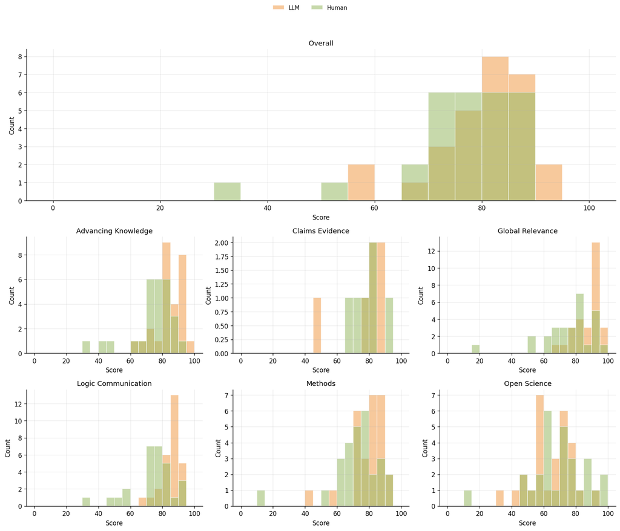

```python
from matplotlib.gridspec import GridSpec

def _plot_hist_for_metric(ax, df_long, metric, bins, title=None):
    g = df_long[df_long["metric"] == metric]
    ax.hist(g[g["rater"]=="LLM"]["score"],   bins=bins, alpha=0.55, label="LLM",
            color=UJ_ORANGE, edgecolor="white")
    ax.hist(g[g["rater"]=="Human"]["score"], bins=bins, alpha=0.55, label="Human",
            color=UJ_GREEN,  edgecolor="white")
    ax.set_title(title or metric.replace("_", " ").title())
    ax.set_xlabel("Score"); ax.set_ylabel("Count")

metrics_all = list(ratings_long["metric"].dropna().unique())
has_overall = "overall" in metrics_all
metrics_others = [m for m in sorted(metrics_all) if m != "overall"]

# bins logic
smin, smax = ratings_long["score"].min(), ratings_long["score"].max()
bins = np.arange(0, 101, 5) if (0 <= smin and smax <= 100) else np.linspace(smin, smax, 21)

if has_overall:
    cols = 3
    rows_other = math.ceil(len(metrics_others) / cols) or 1
    fig = plt.figure(figsize=(cols*4.6, 1.2*3.8 + rows_other*3.6))
    gs = GridSpec(nrows=rows_other+1, ncols=cols, figure=fig,
                  height_ratios=[1.3] + [1]*rows_other)

    # Big top row: Overall spans all columns
    ax0 = fig.add_subplot(gs[0, :])
    _plot_hist_for_metric(ax0, ratings_long, "overall", bins, title="Overall")

    # Bottom grid: remaining metrics
    for idx, m in enumerate(metrics_others):
        r = 1 + idx // cols
        c = idx % cols
        ax = fig.add_subplot(gs[r, c])
        _plot_hist_for_metric(ax, ratings_long, m, bins)

    # Turn off any empty slots
    total_slots = rows_other * cols
    for empty in range(len(metrics_others), total_slots):
        r = 1 + empty // cols
        c = empty % cols
        fig.add_subplot(gs[r, c]).axis("off")

    # Shared legend once (top center)
    handles, labels = ax0.get_legend_handles_labels()
    fig.legend(handles, labels, loc="upper center", ncol=2, frameon=False)
    plt.tight_layout(rect=(0,0,1,0.94))
else:
    # fallback to simple grid if no overall
    metrics = sorted(metrics_all)
    n = len(metrics); cols = 3; rows = math.ceil(n/cols)
    fig, axes = plt.subplots(rows, cols, figsize=(cols*4.6, rows*3.6), sharex=True)
    axes = np.atleast_2d(axes); axes_flat = axes.flat
    for ax, m in zip(axes_flat, metrics):
        _plot_hist_for_metric(ax, ratings_long, m, bins)
    for ax in list(axes_flat)[n:]:
        ax.axis("off")
    handles, labels = axes_flat[0].get_legend_handles_labels()
    fig.legend(handles, labels, loc="upper center", ncol=2, frameon=False)
    plt.tight_layout(rect=(0,0,1,0.94))
```

## Differences by paper and metric

For each *(paper, metric)*, we plot LLM − Human difference in Figure 3.3. Green means the LLM is lower than the human midpoint; orange means higher.

- Vertical stripes (by metric) suggest a metric‑specific bias (LLM systematically up/down on that metric).
- Horizontal stripes (by paper) flag paper‑specific disagreement (LLM consistently above/below for that paper across metrics).
- Isolated bright cells highlight individual outliers worth auditing qualitatively.

Figure 3.3: LLM − Human difference by paper × metric (robust, centered scale; rows sorted by signed overall difference).

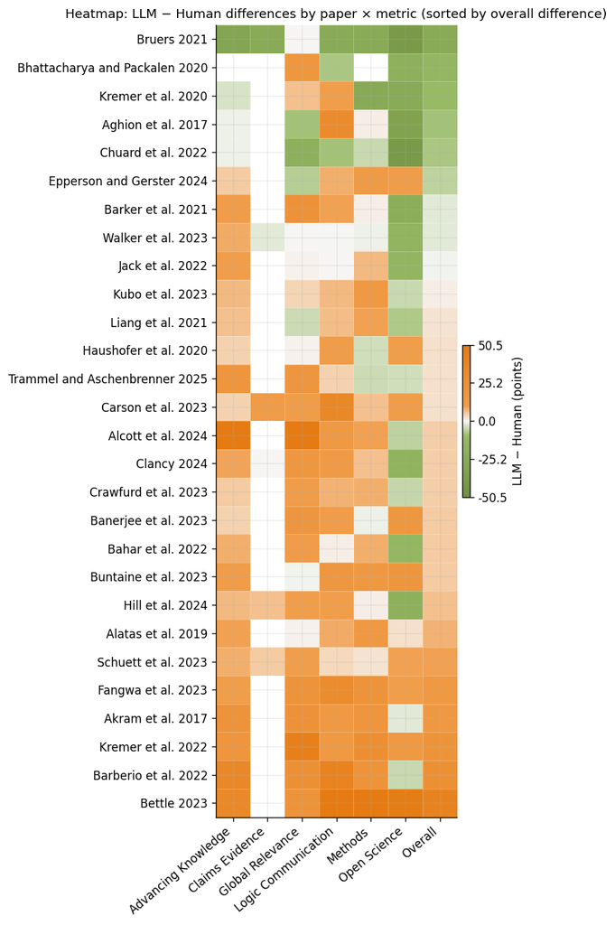

```python
pair = pair_llm_human(merged)
pair["diff"] = pair["LLM"].astype(float) - pair["Human"].astype(float)

# Row order: sort by signed difference on the 'overall' metric (LLM−Human)
order_overall = (pair.loc[pair["metric"]=="overall"]
                   .groupby("paper")["diff"].mean()
                   .sort_values())  # ascending: LLM lower (green) at top, higher (orange) at bottom

hm = pair.pivot_table(index="paper", columns="metric", values="diff", aggfunc="mean")
# apply row order; append any papers lacking 'overall' at the bottom
ordered_rows = list(order_overall.index) + [p for p in hm.index if p not in order_overall.index]
hm = hm.loc[ordered_rows]

Z = hm.values.astype(float)

# Robust centered normalization (as before)
pos = Z[Z > 0]; neg = -Z[Z < 0]
p_hi = np.nanpercentile(pos, 97.5) if pos.size else 0.0
n_hi = np.nanpercentile(neg, 97.5) if neg.size else 0.0
span = max(p_hi, n_hi)
if not np.isfinite(span) or span == 0:
    span = float(np.nanmax(np.abs(Z))) if np.isfinite(np.nanmax(np.abs(Z))) else 1.0

norm = TwoSlopeNorm(vmin=-span, vcenter=0.0, vmax=span)

fig_hm, ax = plt.subplots(
    figsize=(max(6.5, 0.8*hm.shape[1]), max(6.0, 0.40*hm.shape[0]))
)
im = ax.imshow(Z, cmap=UJ_DIV, norm=norm, aspect="auto", interpolation="nearest")

ax.set_xticks(np.arange(hm.shape[1]), labels=[c.replace("_", " ").title() for c in hm.columns], rotation=40, ha="right")
ax.set_yticks(np.arange(hm.shape[0]), labels=hm.index.tolist())

ax.set_xticks(np.arange(-0.5, hm.shape[1], 1), minor=True)
ax.set_yticks(np.arange(-0.5, hm.shape[0], 1), minor=True)
ax.grid(which="minor", color="white", linewidth=0.6)
ax.tick_params(which="minor", bottom=False, left=False)

cb = plt.colorbar(im, ax=ax, fraction=0.03, pad=0.02)
cb.set_label("LLM − Human (points)")
tick_vals = np.linspace(-span, span, 5)
cb.set_ticks(tick_vals); cb.set_ticklabels([f"{t:.1f}" for t in tick_vals])

ax.set_title("Heatmap: LLM − Human differences by paper × metric (sorted by overall difference)")
plt.tight_layout()
```

## Agreement metrics

Table 3.2 shows “calibration” results based on a simple linear regression; Figure 3.4 plots the width of human raters CI against the difference in ratings; and Table 3.4 lists the papers with the largest aabsolute difference between LLM and human raters.

```python
agree_cat = agreement_summary(merged, n_bins=5, bin_strategy="quantile")
agree_cat.round({"pearson":3,"spearman":3,"mean_bias":2,"median_bias":2,
                 "kappa_unw":3,"kappa_quad":3})

ov = overall_stats(merged, n_bins=5, bin_strategy="quantile")


agree_view = (agree_cat
              .rename(columns={"kappa_unw":"kappa_unwtd","kappa_quad":"kappa_quad"})
              .loc[:, ["metric","n","pearson","spearman","mean_bias","median_bias","kappa_unwtd","kappa_quad"]]
              .sort_values("metric"))
agree_view = agree_view.round({"pearson":3, "spearman":3, "mean_bias":2, "median_bias":2, "kappa_unwtd":3, "kappa_quad":3})
agree_view
```

Table 3.1: Agreement metrics by metric (Pearson, Spearman, mean/median bias, κ unweighted/weighted).

|  | metric | n | pearson | spearman | mean_bias | median_bias | kappa_unwtd | kappa_quad |
| --- | --- | --- | --- | --- | --- | --- | --- | --- |
| 0 | advancing_knowledge | 27 | 0.091 | 0.319 | 10.49 | 8.00 | -0.005 | 0.140 |
| 1 | claims_evidence | 6 | 0.594 | 0.897 | -0.58 | 2.50 | 0.333 | 0.778 |
| 2 | global_relevance | 28 | 0.068 | 0.088 | 11.75 | 10.50 | 0.152 | 0.077 |
| 3 | logic_communication | 28 | -0.015 | 0.108 | 11.37 | 9.75 | -0.046 | -0.049 |
| 4 | methods | 27 | 0.264 | 0.398 | 7.60 | 7.00 | 0.112 | 0.257 |
| 5 | open_science | 28 | 0.251 | 0.189 | -5.19 | -5.25 | 0.006 | 0.159 |
| 6 | overall | 28 | 0.277 | 0.412 | 3.71 | 3.50 | 0.068 | 0.392 |

```python
from scipy.stats import linregress

def calibrate_per_metric(merged_df):
    P = pair_llm_human(merged_df)
    rows = []
    for m, g in P.groupby("metric"):
        x, y = g["LLM"].to_numpy(), g["Human"].to_numpy()
        if len(g) >= 2:
            lr = linregress(x, y)  # slope, intercept, rvalue, pvalue, stderr
            yhat = lr.slope * x + lr.intercept
            mad_pre  = float(np.mean(np.abs(x - y)))
            mad_post = float(np.mean(np.abs(yhat - y)))
            rows.append(dict(
                metric=m,
                n=len(g),
                slope=lr.slope, intercept=lr.intercept,
                r2=lr.rvalue**2,
                MAD_pre=mad_pre, MAD_post=mad_post,
                MAD_delta=mad_pre - mad_post
            ))
        else:
            rows.append(dict(metric=m, n=len(g),
                             slope=np.nan, intercept=np.nan, r2=np.nan,
                             MAD_pre=np.nan, MAD_post=np.nan, MAD_delta=np.nan))
    out = pd.DataFrame(rows).sort_values("metric").reset_index(drop=True)
    return out

calib = calibrate_per_metric(merged).copy()
calib_rounded = calib.copy()
for c in ["slope","intercept","r2","MAD_pre","MAD_post","MAD_delta"]:
    calib_rounded[c] = calib_rounded[c].round(3)
calib_rounded
```

Table 3.2: Calibration of LLM to Human by metric (Human ≈ intercept + slope·LLM). Includes pre-/post- MAD.

|  | metric | n | slope | intercept | r2 | MAD_pre | MAD_post | MAD_delta |
| --- | --- | --- | --- | --- | --- | --- | --- | --- |
| 0 | advancing_knowledge | 27 | 0.146 | 60.780 | 0.008 | 13.105 | 9.065 | 4.040 |
| 1 | claims_evidence | 6 | 0.330 | 52.024 | 0.352 | 8.417 | 5.255 | 3.162 |
| 2 | global_relevance | 28 | 0.155 | 61.310 | 0.005 | 14.732 | 11.990 | 2.743 |
| 3 | logic_communication | 28 | -0.035 | 75.939 | 0.000 | 14.393 | 9.830 | 4.563 |
| 4 | methods | 27 | 0.366 | 42.401 | 0.070 | 12.580 | 9.445 | 3.135 |
| 5 | open_science | 28 | 0.332 | 47.347 | 0.063 | 16.155 | 13.205 | 2.950 |
| 6 | overall | 28 | 0.371 | 46.080 | 0.077 | 9.220 | 7.636 | 1.584 |

```python
cov = (merged.dropna(subset=["lower_llm","upper_llm","lower_human","upper_human",
                             "midpoint_llm","midpoint_human"])
              .copy())

cov["human_in_llm"] = (cov["midpoint_human"] >= cov["lower_llm"]) & (cov["midpoint_human"] <= cov["upper_llm"])
cov["llm_in_human"] = (cov["midpoint_llm"]   >= cov["lower_human"]) & (cov["midpoint_llm"]   <= cov["upper_human"])
cov["both_cover"]   = cov["human_in_llm"] & cov["llm_in_human"]

coverage_tbl = (cov.groupby("metric", as_index=False)
                  .agg(N=("paper","size"),
                       human_in_llm=("human_in_llm","mean"),
                       llm_in_human=("llm_in_human","mean"),
                       both_cover=("both_cover","mean")))
coverage_tbl[["human_in_llm","llm_in_human","both_cover"]] = \
    coverage_tbl[["human_in_llm","llm_in_human","both_cover"]].round(2)

# Overall coverage (glue)
overall_cov = dict(
    N=int(len(cov)),
    human_in_llm=float(cov["human_in_llm"].mean()),
    llm_in_human=float(cov["llm_in_human"].mean()),
    both=float(cov["both_cover"].mean())
)
# glue("cov_both", overall_cov["both"])
# glue("cov_hinl", overall_cov["human_in_llm"])
# glue("cov_linh", overall_cov["llm_in_human"])

coverage_tbl
```

Table 3.3: CI coverage: does one interval contain the other’s point estimate?

|  | metric | N | human_in_llm | llm_in_human | both_cover |
| --- | --- | --- | --- | --- | --- |
| 0 | advancing_knowledge | 24 | 0.54 | 0.54 | 0.42 |
| 1 | claims_evidence | 6 | 0.67 | 0.67 | 0.67 |
| 2 | global_relevance | 25 | 0.32 | 0.44 | 0.28 |
| 3 | logic_communication | 25 | 0.32 | 0.52 | 0.28 |
| 4 | methods | 24 | 0.58 | 0.50 | 0.42 |
| 5 | open_science | 25 | 0.48 | 0.40 | 0.32 |
| 6 | overall | 25 | 0.52 | 0.76 | 0.52 |

Figure 3.4: Human uncertainty (CI width) vs |LLM − Human|. Spearman correlation reported.

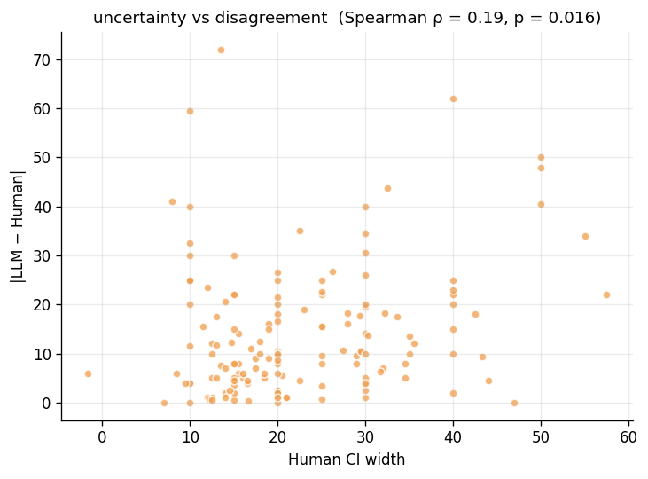

```python
use = merged.dropna(subset=["lower_human","upper_human","midpoint_llm","midpoint_human"]).copy()
use["human_width"] = use["upper_human"] - use["lower_human"]
use["abs_diff"]    = (use["midpoint_llm"] - use["midpoint_human"]).abs()

rho, pval = (np.nan, np.nan)
if len(use) >= 3:
    rho, pval = spearmanr(use["human_width"], use["abs_diff"])

fig, ax = plt.subplots(figsize=(6.2, 4.6))
ax.scatter(use["human_width"], use["abs_diff"], s=28, alpha=.75, color=UJ_ORANGE, edgecolor="white")
ax.set_xlabel("Human CI width")
ax.set_ylabel("|LLM − Human|")
ax.set_title(f"uncertainty vs disagreement  (Spearman ρ = {rho:.2f}, p = {pval:.3f})")
ax.grid(True, alpha=.25)
plt.tight_layout()
```

```python
out = merged.copy()
out["abs_diff"] = (out["midpoint_llm"] - out["midpoint_human"]).abs()
out["human_in_llm"] = (out["midpoint_human"] >= out["lower_llm"]) & (out["midpoint_human"] <= out["upper_llm"])
out["llm_in_human"] = (out["midpoint_llm"]   >= out["lower_human"]) & (out["midpoint_llm"]   <= out["upper_human"])
cols = ["paper","metric","midpoint_llm","midpoint_human","abs_diff","human_in_llm","llm_in_human"]
outliers = (out.sort_values("abs_diff", ascending=False)
              .loc[:, cols]
              .head(15))
outliers
```

Table 3.4: Top absolute differences (LLM vs Human). Flags show whether each point lies within the other’s CI.

|  | paper | metric | midpoint_llm | midpoint_human | abs_diff | human_in_llm | llm_in_human |
| --- | --- | --- | --- | --- | --- | --- | --- |
| 23 | Alcott et al. 2024 | global_relevance | 88 | 16.00 | 72.00 | False | False |
| 49 | Bettle 2023 | methods | 72 | 10.00 | 62.00 | False | False |
| 20 | Alcott et al. 2024 | advancing_knowledge | 92 | 32.50 | 59.50 | False | False |
| 51 | Bettle 2023 | logic_communication | 80 | 30.00 | 50.00 | False | False |
| 52 | Bettle 2023 | open_science | 58 | 10.00 | 48.00 | False | False |
| 139 | Kremer et al. 2022 | global_relevance | 95 | 51.25 | 43.75 | False | False |
| 82 | Chuard et al. 2022 | open_science | 55 | 96.00 | 41.00 | False | False |
| 48 | Bettle 2023 | overall | 73 | 32.50 | 40.50 | False | False |
| 39 | Barberio et al. 2022 | logic_communication | 85 | 45.00 | 40.00 | False | False |
| 63 | Bruers 2021 | open_science | 40 | 80.00 | 40.00 | False | False |
| 75 | Carson et al. 2023 | logic_communication | 85 | 50.00 | 35.00 | False | False |
| 38 | Barberio et al. 2022 | advancing_knowledge | 82 | 47.50 | 34.50 | False | False |
| 50 | Bettle 2023 | advancing_knowledge | 74 | 40.00 | 34.00 | False | True |
| 4 | Aghion et al. 2017 | open_science | 55 | 87.50 | 32.50 | False | False |
| 3 | Aghion et al. 2017 | logic_communication | 88 | 57.50 | 30.50 | False | False |